# Introduction au DataViz Grammaire des Graphiques

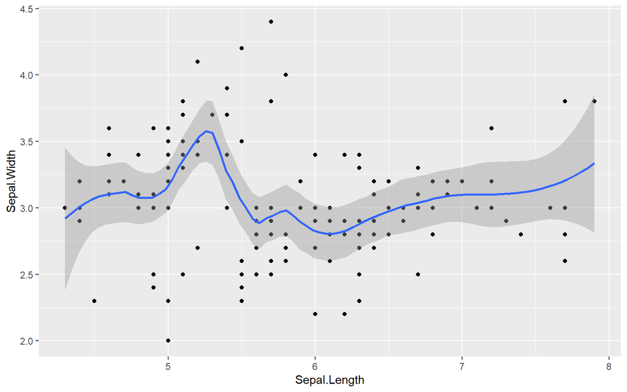

    ```r
    SecondGraph
    ```

39. Dans `geom_smooth`, utiliser le paramètre `method` pour visualiser une régression linéaire (`"lm"`)

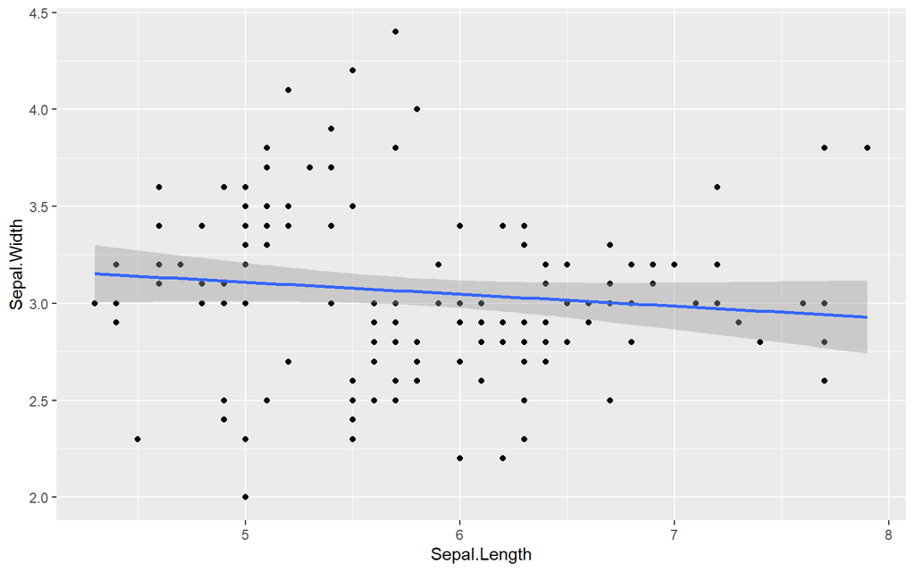

    ```r
    SecondGraph <- ggplot(data = iris, aes(x = Sepal.Length, y = Sepal.Width)) + geom_point() + geom_smooth(method = "lm")
    SecondGraph
    ```

40. Utiliser `geom_smooth()` et `facet_wrap` pour afficher dans un même graphe les nuage de points et la droite de regression en fonction de l’espèce

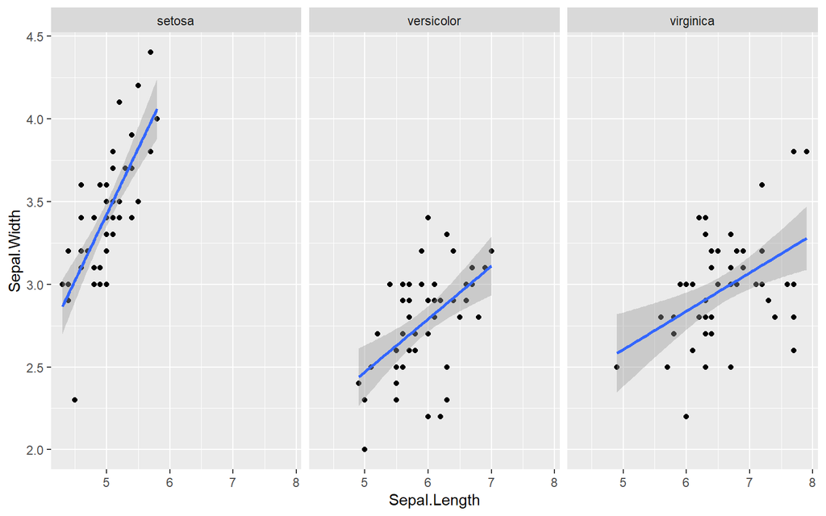

    ```r
    SecondGraph <- ggplot(data = iris, aes(x = Sepal.Length, y = Sepal.Width)) + geom_point() + geom_smooth(method = "lm") + facet_wrap(~Species)
    SecondGraph
    ```

41. Ajouter une couleur respective à l’espèce représentée et régénérer et visualiser le grpahique ci-dessus

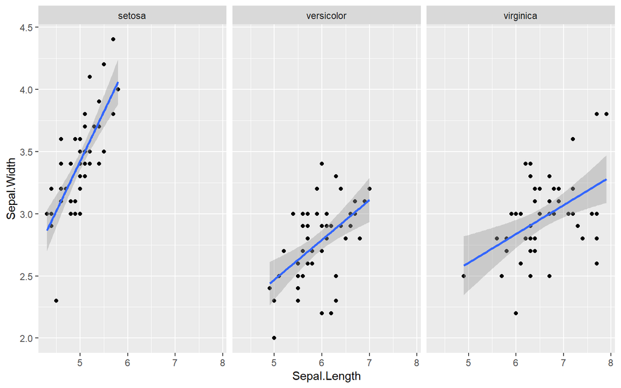

    ```r
    SecondGraph <- ggplot(data = iris, aes(x = Sepal.Length, y = Sepal.Width)) + geom_point() + geom_smooth(method = "lm") + facet_wrap(~Species) + scale_colour_brewer(palette = "Set2")
    SecondGraph
    ```

42. Ajouter sucessivement les trois themes `theme_bw()`, `theme_dark(`) et `theme_light()` régénérer et visualiser le grpahique ci-dessus pour chaque theme

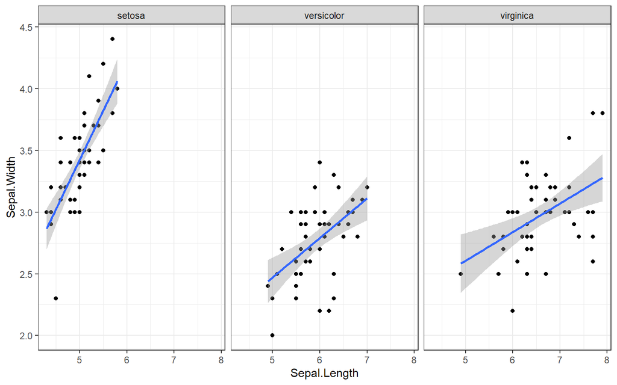

    ```r
    SecondGraph <- ggplot(data = iris, aes(x = Sepal.Length, y = Sepal.Width)) + geom_point() + geom_smooth(method = "lm") + facet_wrap(~Species) + scale_colour_brewer(palette = "Set2") + theme_bw()
    SecondGraph
    ```

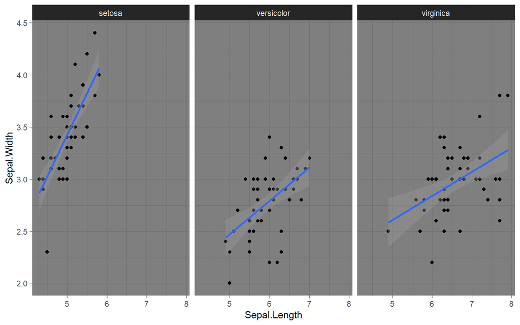

    ```r
    SecondGraph <- ggplot(data = iris, aes(x = Sepal.Length, y = Sepal.Width)) + geom_point() + geom_smooth(method = "lm") + facet_wrap(~Species) + scale_colour_brewer(palette = "Set2") + theme_dark()
    SecondGraph
    ```

43. Utiliser `SecondGraph` et donner une couleur aux points respective à l’espèce représentée et enregistrer le tout dans `GraphCouleur`

Utiliser `SecondGraph` et la fonction scale_colour_brewer() avec les deux `palette="Set2" et "sect3"`

```r
SecondGraph <- ggplot(data = iris, aes(x = Sepal.Length, y = Sepal.Width)) + geom_point() + geom_smooth(method = "lm") + facet_wrap(~Species) + scale_colour_brewer(palette = "Set2") + theme_light()
SecondGraph
SecondGraph <- ggplot(data = iris, aes(x = Sepal.Length, y = Sepal.Width)) + geom_point() + geom_smooth(method = "lm") + facet_wrap(~Species) + scale_colour_brewer(palette = "Set3") + theme_light()
SecondGraph
```

44. Utiliser `SecondGraph` et ajouter `scale_colour_manual(values = c("rosybrown","tomato","midnightblue"))`

45. Utiliser `GraphCouleur` et ajouter un titre à l’aide de la fonction `ggtitle`. Utiliser les paramètres suivants pour le theme `theme(legend.position = "bottom", legend.title = element_text(face="bold"), axis.title.x = element_text(face="italic"), plot.title = element_text(colour = "purple",size = rel(1.5)))`

[figure not shown]

    ```r
    GraphCouleur <- GraphCouleur + ggtitle("Nuage de points et droite de regression en fonction de l'espèce") + theme(legend.position = "bottom",
            legend.title = element_text(face="bold"),
            axis.title.x = element_text(face="italic"),
            plot.title = element_text(colour = "purple",size = rel(1.5)))
    GraphCouleur
    ```